# Generating Pooled Seurat Object

Data processing

Seurat

Demultiplexing

Integration

Shows how the full DOGMA-seq gut dataset was assembled by looping over every library to create a Seurat object with RNA, HTO, and ADT assays, demultiplexing the pooled samples along the way. Merges the libraries, filters cells by mitochondrial content, and runs the standard RNA workflow of normalization, PCA, Harmony integration, UMAP, and clustering.

Author

Noor Sohail

Published

October 31, 2026

Keywords

merge Seurat objects, for loop Seurat multiple samples, Read10X multiple samples, cellranger-arc per_barcode_metrics, HTODemux pooled samples, Seurat JoinLayers, mitochondrial ratio filtering, Harmony integration Seurat, scRNA-seq clustering workflow, DOGMA-seq Seurat processing

## Learning objectives

In this lesson, we will:

- Automate loading and demultiplexing many samples with a `for` loop
- Merge per-sample Seurat objects and filter cells on mitochondrial content
- Process the RNA assay with normalization, PCA, Harmony, UMAP, and clustering

## Overview of lesson

In this lesson, we through each of the steps that were used in order to concatenate each sample into a singular Seurat object. In the process, pooled samples were demultiplexed. Lastly, the combined Seurat object was then taken through a standard scRNA-seq workflow through to clustering.

## Create Seurat object

First, we set up the script so that we can loop through multiple samples with a `for` loop. So we keep track of the sample names and create an empty list where we will store the Seurat objects. Additionally, as some of the datasets are pooled, we will need to run the demultiplexing steps for them in this step, so we create `samples_pooled` to keep track of which samples those are.

```r
### Load libraries
library(tidyverse)
library(Seurat)
library(qs)
library(harmony)

### Metadata
df_meta <- read.csv("data_dogma_hiv/GSE299348/samples.tsv", sep = "\t")
rownames(df_meta) <- df_meta$library

### Load every dataset
# List of seurat object to eventually merge
list_seurat <- list()

# Note pooled samples to dehash later
samples_pooled <- c("PT1", "PT2", "PT3")
```

Next, we loop through each library in our metadata and build one Seurat object per sample. For every sample, the loop:

1. **Selects real cells.** We read the `per_barcode_metrics.csv.gz` file from the ATAC output of `cellranger-arc` and keep only the barcodes where `is_cell == 1`. This removes the empty droplets from the raw matrices so that the RNA and protein data contain the same set of cells as the ATAC data.
2. **Creates the Seurat object.** We load the counts from the `ADT` folder, subset the “Gene Expression” matrix to our cells, and create the `RNA` assay. We also record the `patient` and `hiv_status` from the metadata.
3. **Separates hashtags from proteins.** The “Antibody Capture” matrix holds both the hashtags and the surface proteins. For pooled samples, we read `hashing_info.txt.gz` and store only the hashtags used in that pool as the `HTO` assay. Every other antibody that is not a hashtag is stored as the `ADT` assay.
4. **Demultiplexes pooled samples.** For the samples in `samples_pooled`, we remove low-count cells, CLR-normalize the hashtags, and run `HTODemux()`, just as we did for `PT1` in the previous lesson. We keep only the cells confidently assigned to a single hashtag and replace the `patient` column with the patient matched to that hashtag.
5. **Stores the result.** We prefix the patient IDs with `patient_` so they are read as text rather than numbers, and add the object to `list_seurat` under the sample name.

```r
# Loop through each sample
for (sample in df_meta$library) {

  print(sample)
  patient <- df_meta[sample, "patient"]
  hiv_status <- df_meta[sample, "hiv_status"]

  ### Get cells of interest
  cells <- read.csv(file.path("data_dogma_hiv/",
                              "GSE299348/", sample,
                              "/ATAC/per_barcode_metrics.csv.gz")) %>%
    subset(is_cell == 1) %>%
    pull(barcode)

  ### Load counts
  counts <- Read10X(file.path("data_dogma_hiv",
                              "GSE299348",
                              sample,
                              "ADT"))

  ### RNA expression
  counts_gex <- counts[["Gene Expression"]]
  counts_gex <- counts_gex[, cells]

  ### Create seurat object
  seurat <- CreateSeuratObject(
    counts = counts_gex,
    assay = "RNA",
    project = sample)
  seurat$patient <- patient
  seurat$hiv_status <- hiv_status

  ### ADT and hashtags
  counts_anitbody <- counts[["Antibody Capture"]]
  counts_anitbody <- counts_anitbody[, cells]
  # Features all have _TotalA appended
  rownames(counts_anitbody) <- str_replace_all(rownames(counts_anitbody), "_TotalA", "")


  ### Hashtag counts
  # 8 hashtag sequences
  hashes <- paste0("hashtag", seq(1, 8))
  if (sample %in% samples_pooled) {
    df_hash <- read.csv(file.path("data_dogma_hiv",
                                  "GSE299348", sample,
                                  "ADT", "hashing_info.txt.gz"),
                        header = FALSE, sep = ":",
                        col.names = c("hash", "patient")) %>%
      # Fix capitalization and whitespace
      mutate(hash = str_replace(hash, "H", "h"),
             hash = str_replace(hash, " ", ""))

    # Hashtag matrix
    counts_hash <- counts_anitbody[df_hash$hash, Cells(seurat), drop = FALSE]
    seurat[["HTO"]] <- CreateAssayObject(counts = counts_hash)
  }

  ### Protein counts
  counts_adt <- counts_anitbody[!rownames(counts_anitbody) %in% hashes, Cells(seurat)]
  seurat[["ADT"]] <- CreateAssayObject(counts = counts_adt)

  ### Demultiplex hashtags
  if (sample %in% samples_pooled) {
    seurat <- subset(seurat, nCount_ADT > 30)

    # CLR HTO normalization
    seurat <- NormalizeData(
      seurat,
      assay = "HTO",
      normalization.method = "CLR",
      margin = 2)

    # HTO demultiplexing
    seurat <- HTODemux(
      seurat,
      assay = "HTO",
      positive.quantile = 0.99,
      verbose = TRUE)

    # Remove negative and doublets (only keep confident hash)
    seurat <- subset(seurat, subset = hash.ID %in% df_hash$hash)
    seurat$patient <- df_hash$patient[match(seurat$hash.ID, df_hash$hash)]
  }

  # Turn patient column into string
  seurat$patient <- paste0("patient_", seurat$patient)

  # Store results in list
  list_seurat[[sample]] <- seurat

}
```

Now that we have create a Seurat object for each sample, we can now merge all datasets together. We can do this with the `merge()` and `JoinLayers()` function.

```r
### Merge all datasets together
seurat <- merge(
  x = list_seurat[[1]],
  y = list_seurat[2: length(list_seurat)],
  add.cell.ids = names(list_seurat)
)

Idents(seurat) <- "orig.ident"
DefaultAssay(seurat) <- "RNA"
seurat <- JoinLayers(seurat)
```

In the method section of the paper, they also mentioned that they removed cells with > 25% mitochondrial ratio to further clean up the dataset.

```r
# Compute percent mito ratio
seurat$mitoRatio <- PercentageFeatureSet(object = seurat, pattern = "^MT-")
seurat$mitoRatio <- seurat@meta.data$mitoRatio / 100
seurat <- subset(seurat, mitoRatio < 0.25)
```

## Processing the Seurat object

With all the cells loaded, we can begin the standard processing steps. This entails:

- Normalization
- Variable feature selection
- Scaling counts and running PCA
- Assessing batch effect and running `Harmony` to integrate samples
- UMAP
- Shared nearest neighbors
- Clustering

```r
### Process RNA
DefaultAssay(seurat) <- "RNA"
seurat <- NormalizeData(seurat)
seurat <- FindVariableFeatures(seurat, nfeatures = 2000)
seurat <- ScaleData(seurat)
seurat <- RunPCA(seurat, npcs = 50, reduction.name = "pca_rna", verbose = FALSE)

seurat <- RunHarmony(seurat, group.by.vars = "orig.ident",
                     reduction.use = "pca_rna", dims.use = 1:30,
                     reduction.save = "harmony_rna", verbose = FALSE)
seurat <- RunUMAP(seurat, reduction = "harmony_rna", dims = 1:30,
                  reduction.name = "umap_rna", reduction.key = "rnaUMAP_",
                  verbose = FALSE)

seurat <- FindNeighbors(seurat, reduction = "harmony_rna", dims = 1:30,
                        graph.name = c("nn_rna", "snn_rna"), verbose = FALSE)
seurat <- FindClusters(seurat, graph.name = "snn_rna", resolution = 0.8,
                       cluster.name = "clusters_rna", verbose = FALSE)
```

### UMAP visualizations

This takes us to the point of where we can load in our Seurat object:

```r
# Load libraries and data
library(Seurat)
library(tidyverse)

seurat_demux <- readRDS("data/processed_seurat_objects/seurat_demux.RDS")
```

The UMAP coordinates were computed on the harmony corrected latent space, which we can visualize here to give a quick overview of if the integration was succesful.

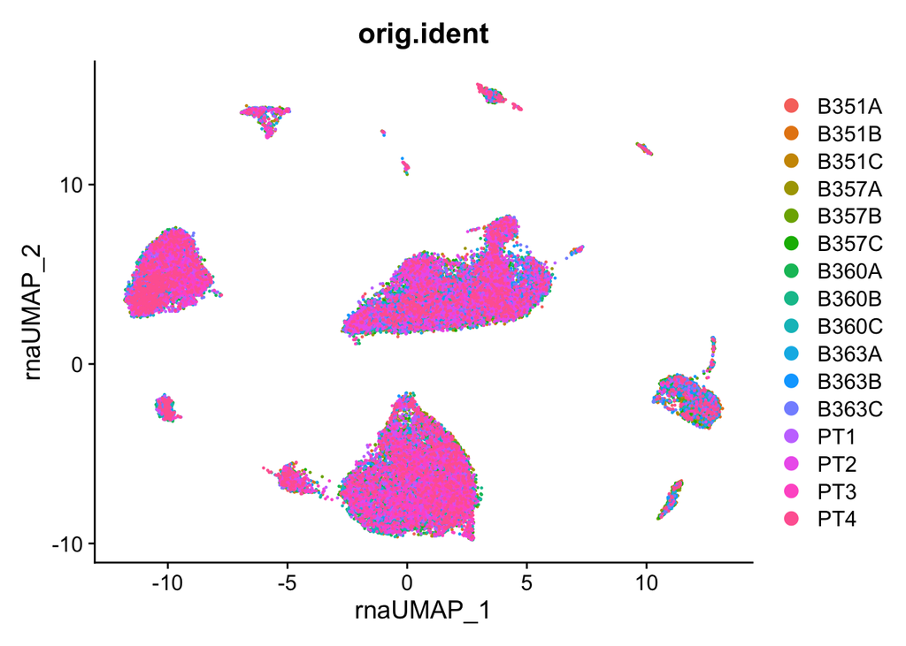

Figure 1: UMAP of the Harmony-integrated RNA expression, colored by sample.

```r
DimPlot(seurat_demux,
        group.by = "orig.ident",
        reduction = "umap_rna")
```

We additionally clustered the cells at a resolution of `0.8`

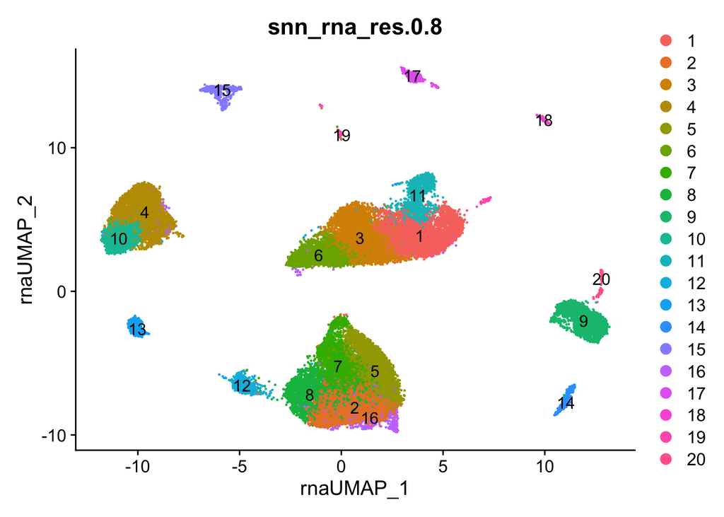

Figure 2: UMAP of the Harmony-integrated RNA expression, colored by clusters at a resolution of 0.8.

```r
DimPlot(seurat_demux,
        group.by = "snn_rna_res.0.8",
        reduction = "umap_rna",
        label = TRUE)
```

Back to Lesson >>

Back to Schedule